# Praca domowa 8 - Techniki Wizualizacji Danych

Analiza eksploracyjna zbioru danych world happiness

Michał Tomczyk

# Wstęp

W ramach ósmej pracy domowej z Technik Wizualizacji Danych miałem przeanalizować zbiór world happiness. Sprawdźmy jakie kolumny ma ta ramka:

```
##  [1] "Country"                       "Region"
##  [3] "Happiness.Rank"                "Happiness.Score"
##  [5] "Standard.Error"                "Economy..GDP.per.Capita."
##  [7] "Family"                        "Health..Life.Expectancy."
##  [9] "Freedom"                       "Trust..Government.Corruption."
## [11] "Generosity"                    "Dystopia.Residual"
```

# Pierwsze obserwacje

Można podejrzeć które kraje są najszczęśliwsze i jaki mają wskaźnik szczęścia:

| Country | Happiness.Score |
| --- | --- |
| Switzerland | 7.587 |
| Iceland | 7.561 |
| Denmark | 7.527 |
| Norway | 7.522 |
| Canada | 7.427 |
| Finland | 7.406 |
| Netherlands | 7.378 |
| Sweden | 7.364 |
| New Zealand | 7.286 |
| Australia | 7.284 |

A także jaka jest średnia wskaźnika szczęścia dla danego regionu:

| Region | Średnia |
| --- | --- |
| Australia and New Zealand | 7.285000 |
| Central and Eastern Europe | 5.332931 |
| Eastern Asia | 5.626167 |
| Latin America and Caribbean | 6.144682 |
| Middle East and Northern Africa | 5.406900 |
| North America | 7.273000 |
| Southeastern Asia | 5.317444 |
| Southern Asia | 4.580857 |
| Sub-Saharan Africa | 4.202800 |
| Western Europe | 6.689619 |

# Korelacje między zmiennymi

Sprawdźmy jakie zmienne korelują ze sobą:

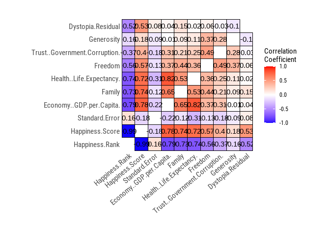

Teraz sprawdźmy jaka jest dystrybucja zmiennych w zbiorze:

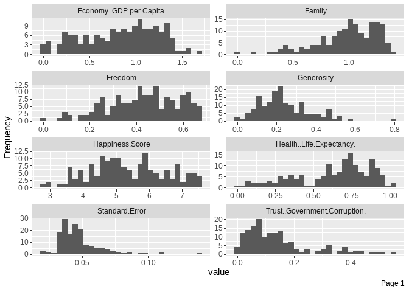

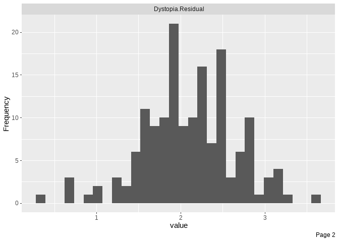

Zbadajmy zależność wskaźnika wolności od wskaźnika zaufania do rządu w sprawie korupcji:

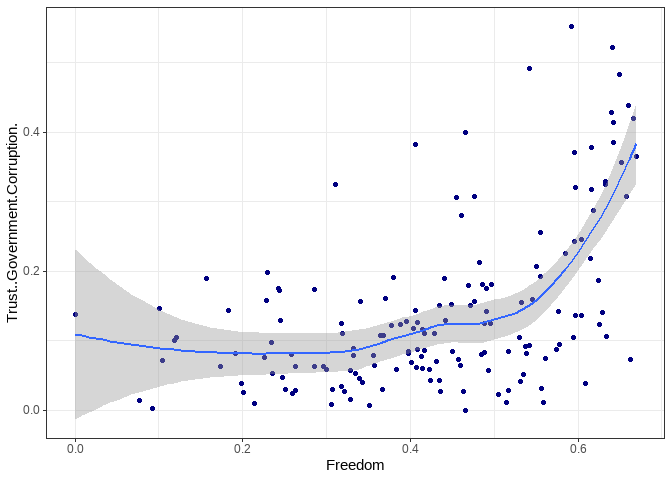

W podobny sposób możemy zbadać zależność wskaźnika ekonomii od wskaźnika zdrowia:

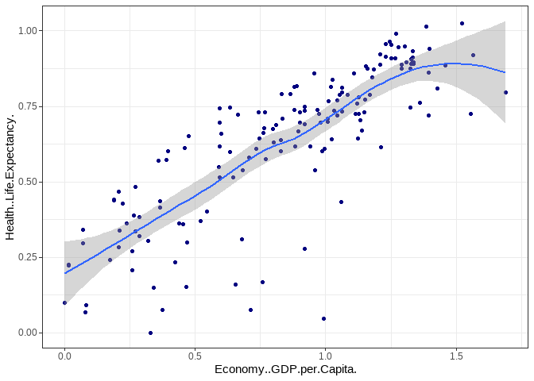

Więcej powie nam rozkład poszczególnych zmiennych dla danych regionów:

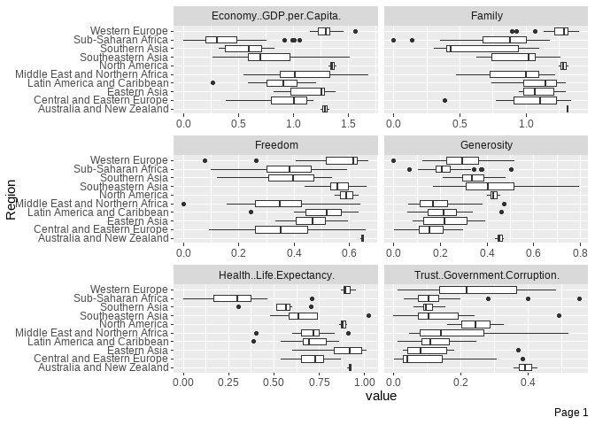

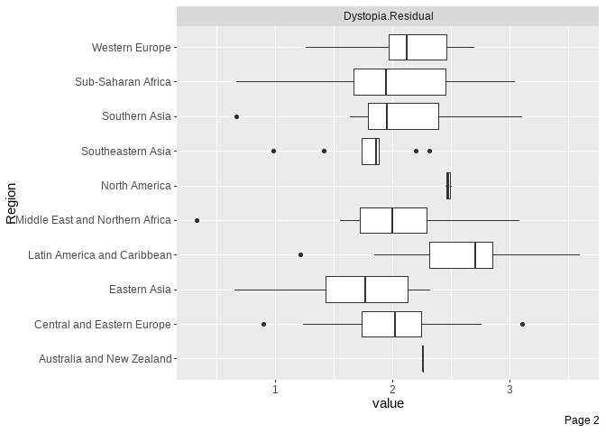

# Wnioski

Możemy spostrzec, że według tego zbioru w 2015 r. byli mieszkańcy Ameryki Północnej, Australii i Nowej Zelandii oraz Europy Zachodniej, przy czym ten ostatni region ma dużo większe rozbieżności, np. w kwestii zaufania do rządu, lecz jest to wskaźnik, którego wartości są rozbieżne w większości regionów. Na uwagę zasługuje fakt jak bardzo Afryka Subsaharyjska odstaje pod kątem zdrowia od reszty świata oraz to jak kraje w tym regionie, ale także w Centralnej i Środkowej Europie są zróżnicowane pod kątem wolności. Ciekawa też jest zależność wskaźnika wolności od wskaźnika zaufania do rządu w sprawie korupcji - tylko najbardziej wolne kraje ufają rządzącym, dla reszty świata to zaufanie oscyluje w podobnych wartościach. Widzimy też jak duży wpływ na zdrowie w danym kraju ma czynnik ekonomiczny.